# WIM Workshop

Meltem Odabas

12/11/2019

# Welcome to WIM Workshop on R for Stats!

## Outline of the Workshop

- How to find datasets on R?
- Data Cleaning
- Descriptive Statistics
- (Very!) Basic data visualizations
- Regression analysis + post-estimation tests

## Before we start … some resources

*Learning How to use R*

Swirl Lessons: https://swirlstats.com/students.html

*Importing Data* Data import cheat sheet: https://github.com/rstudio/cheatsheets/raw/master/data-import.pdf

*For data cleaning*

Online textbook: https://cran.r-project.org/doc/contrib/de_Jonge+van_der_Loo-Introduction_to_data_cleaning_with_R.pdf

*For data summaries and data visualization* gglot2 tutorial: https://jcoliver.github.io/learn-r/014-intro-summarizing-visualizing.html

various packages for data summaries: https://dabblingwithdata.wordpress.com/2018/01/02/my-favourite-r-package-for-summarising-data/

dot-whisker plots for regression coefficient visualization: https://cran.r-project.org/web/packages/dotwhisker/vignettes/dotwhisker-vignette.html

## Using a readily available dataset (either in R or importing another file)

To explore some datasets available in R, you can check:

```r
library(MASS)
data()
```

For today, however, we will import a .csv dataset. There are various functions available for importing a .csv dataset. Let’s try them out.

Ok, so, I will assign the dataset to an element called df (short for dataframe)

```r
df <- read.csv(file="evictionlab_IN.csv", stringsAsFactors = FALSE)
```

Let’s check whether this is actually a dataframe:

```r
class(df)
```

```
## [1] "data.frame"
```

```r
head(df)
```

```
##   GEOID year    name parent.location population poverty.rate
## 1    18 2000 Indiana             USA    6080485         9.49
## 2    18 2001 Indiana             USA    6080485         9.49
## 3    18 2002 Indiana             USA    6080485         9.49
## 4    18 2003 Indiana             USA    6080485         9.49
## 5    18 2004 Indiana             USA    6080485         9.49
## 6    18 2005 Indiana             USA    6342469         9.52
##   renter.occupied.households pct.renter.occupied median.gross.rent
## 1                     222072               28.56               521
## 2                     468860               28.56               521
## 3                     594051               28.56               521
## 4                     597514               28.56               521
## 5                     618317               28.56               521
## 6                     625291               28.51               671
##   median.household.income median.property.value rent.burden pct.white pct.af.am
```

[output cut: 27 more lines]

```r
head(df$poverty.rate)
```

```
## [1] 9.49 9.49 9.49 9.49 9.49 9.52
```

Or we can use the following (which will bring the exact same results!)

```r
head(df[,"poverty.rate"])
```

```
## [1] 9.49 9.49 9.49 9.49 9.49 9.52
```

And we can check the class for the column as well!

```r
class(df$poverty.rate)
```

```
## [1] "numeric"
```

## Looking into your dataset

### Data and Variable Structure (summary stats, a little Cleaning, a little intro to ‘for loops’…)

You can check the variable names of your data with names(df)

```r
names(df)
```

```
##  [1] "GEOID"                      "year"
##  [3] "name"                       "parent.location"
##  [5] "population"                 "poverty.rate"
##  [7] "renter.occupied.households" "pct.renter.occupied"
##  [9] "median.gross.rent"          "median.household.income"
## [11] "median.property.value"      "rent.burden"
## [13] "pct.white"                  "pct.af.am"
## [15] "pct.hispanic"               "pct.am.ind"
## [17] "pct.asian"                  "pct.nh.pi"
## [19] "pct.multiple"               "pct.other"
## [21] "eviction.filings"           "evictions"
## [23] "eviction.rate"              "eviction.filing.rate"
## [25] "low.flag"                   "imputed"
## [27] "subbed"
```

To understand what the structure of your data is, you can simply type str(df)

```r
str(df)
```

```
## 'data.frame':    120718 obs. of  27 variables:
##  $ GEOID                     : num  18 18 18 18 18 18 18 18 18 18 ...
##  $ year                      : int  2000 2001 2002 2003 2004 2005 2006 2007 2008 2009 ...
##  $ name                      : chr  "Indiana" "Indiana" "Indiana" "Indiana" ...
##  $ parent.location           : chr  "USA" "USA" "USA" "USA" ...
##  $ population                : num  6080485 6080485 6080485 6080485 6080485 ...
##  $ poverty.rate              : num  9.49 9.49 9.49 9.49 9.49 9.52 9.52 9.52 9.52 9.52 ...
##  $ renter.occupied.households: num  222072 468860 594051 597514 618317 ...
##  $ pct.renter.occupied       : num  28.6 28.6 28.6 28.6 28.6 ...
##  $ median.gross.rent         : num  521 521 521 521 521 671 671 671 671 671 ...
##  $ median.household.income   : num  41567 41567 41567 41567 41567 ...
##  $ median.property.value     : num  94300 94300 94300 94300 94300 ...
##  $ rent.burden               : num  23.9 23.9 23.9 23.9 23.9 29 29 29 29 29 ...
##  $ pct.white                 : num  85.8 85.8 85.8 85.8 85.8 ...
##  $ pct.af.am                 : num  8.31 8.31 8.31 8.31 8.31 8.56 8.56 8.56 8.56 8.56 ...
##  $ pct.hispanic              : num  3.53 3.53 3.53 3.53 3.53 5.07 5.07 5.07 5.07 5.07 ...
##  $ pct.am.ind                : num  0.22 0.22 0.22 0.22 0.22 0.19 0.19 0.19 0.19 0.19 ...
##  $ pct.asian                 : num  0.96 0.96 0.96 0.96 0.96 1.33 1.33 1.33 1.33 1.33 ...
##  $ pct.nh.pi                 : num  0.03 0.03 0.03 0.03 0.03 0.02 0.02 0.02 0.02 0.02 ...
##  $ pct.multiple              : num  1.01 1.01 1.01 1.01 1.01 1.44 1.44 1.44 1.44 1.44 ...
##  $ pct.other                 : num  0.1 0.1 0.1 0.1 0.1 0.17 0.17 0.17 0.17 0.17 ...
##  $ eviction.filings          : num  7000 28910 52777 56744 58299 ...
##  $ evictions                 : num  6370 19248 26529 28105 32603 ...
##  $ eviction.rate             : num  2.87 4.11 4.47 4.7 5.27 5.33 5.12 4.73 4.76 4.81 ...
##  $ eviction.filing.rate      : num  3.15 6.17 8.88 9.5 9.43 9.92 9.77 9.49 9.2 8.87 ...
##  $ low.flag                  : int  0 0 0 0 0 0 0 0 0 0 ...
##  $ imputed                   : int  0 0 0 0 0 0 0 0 0 0 ...
##  $ subbed                    : int  0 0 0 0 0 0 0 0 0 0 ...
```

```r
head(df,7)
```

```
##   GEOID year    name parent.location population poverty.rate
## 1    18 2000 Indiana             USA    6080485         9.49
## 2    18 2001 Indiana             USA    6080485         9.49
## 3    18 2002 Indiana             USA    6080485         9.49
## 4    18 2003 Indiana             USA    6080485         9.49
## 5    18 2004 Indiana             USA    6080485         9.49
## 6    18 2005 Indiana             USA    6342469         9.52
## 7    18 2006 Indiana             USA    6342469         9.52
##   renter.occupied.households pct.renter.occupied median.gross.rent
## 1                     222072               28.56               521
## 2                     468860               28.56               521
## 3                     594051               28.56               521
## 4                     597514               28.56               521
## 5                     618317               28.56               521
## 6                     625291               28.51               671
```

[output cut: 33 more lines]

```r
tail(df,7)
```

```
##               GEOID year  name         parent.location population poverty.rate
## 120712 181830507003 2010 507.3 Whitley County, Indiana        817         6.85
## 120713 181830507003 2011 507.3 Whitley County, Indiana        558        10.24
## 120714 181830507003 2012 507.3 Whitley County, Indiana        558        10.24
## 120715 181830507003 2013 507.3 Whitley County, Indiana        558        10.24
## 120716 181830507003 2014 507.3 Whitley County, Indiana        558        10.24
## 120717 181830507003 2015 507.3 Whitley County, Indiana        558        10.24
## 120718 181830507003 2016 507.3 Whitley County, Indiana        558        10.24
##        renter.occupied.households pct.renter.occupied median.gross.rent
## 120712                         31               10.20                NA
## 120713                         32               14.11                NA
## 120714                         32               14.11                NA
## 120715                         33               14.11                NA
## 120716                         33               14.11                NA
## 120717                         34               14.11                NA
```

[output cut: 33 more lines]

So it seems like the observations are at year-county level. We can check the total number of observations, and which year and counties are included in the dataset:

```r
nrow(df) #unique number of observations
```

```
## [1] 120718
```

```r
unique(df$year) #takes the year column and shows only the unique observations -- even if there are 48351 observations of 2011, for example, we will see only one in the output...
```

```
##  [1] 2000 2001 2002 2003 2004 2005 2006 2007 2008 2009 2010 2011 2012 2013 2014
## [16] 2015 2016
```

```r
head(unique(df$name)) #takes the name column and shows only the unique observations
```

```
## [1] "Indiana"            "Adams County"       "Allen County"
## [4] "Bartholomew County" "Benton County"      "Blackford County"
```

Clearly there is something funky with the name column… seems like there is a state level observations (i.e., indiana), a number of county-level observations (X County), Cities (Bloomington!) and some other observations identified by some numbers (???) Then, let’s limit our analysis with all observations that has the name “County” in it. This will require some cleaning, right? Also some regular expression stuff…

After some Googling, I find that grepl(value, chars) function finds whether the chars are in a string. So, for example:

```r
df$name[c(1,20,50)] #shows me the 1st, 20th and 50th observations in df$name
```

```
## [1] "Indiana"      "Adams County" "Allen County"
```

```r
df[c(1,20,50),] #shows me the 1st, 20th and 50th observations in df
```

```
##    GEOID year         name parent.location population poverty.rate
## 1     18 2000      Indiana             USA    6080485         9.49
## 20 18001 2002 Adams County         Indiana      33625         9.08
## 50 18003 2015 Allen County         Indiana     363453        12.01
##    renter.occupied.households pct.renter.occupied median.gross.rent
## 1                      222072               28.56               521
## 20                       2741               23.04               393
## 50                      46503               31.15               682
##    median.household.income median.property.value rent.burden pct.white
## 1                    41567                 94300        23.9     85.84
## 20                   40625                 85400        18.8     95.77
## 50                   49092                114600        28.1     75.20
##    pct.af.am pct.hispanic pct.am.ind pct.asian pct.nh.pi pct.multiple pct.other
## 1       8.31         3.53       0.22      0.96      0.03         1.01      0.10
## 20      0.13         3.32       0.14      0.19      0.02         0.40      0.01
## 50     11.34         6.98       0.19      3.16      0.04         2.87      0.22
##    eviction.filings evictions eviction.rate eviction.filing.rate low.flag
## 1              7000      6370          2.87                 3.15        0
## 20               14         3          0.11                 0.51        1
## 50             7095      3628          7.80                15.26        0
##    imputed subbed
## 1        0      0
## 20       0      0
## 50       0      0
```

```r
grepl("County",df$name[1])
```

```
## [1] FALSE
```

```r
grepl("County",df$name[20])
```

```
## [1] TRUE
```

```r
grepl("County",df$name[50])
```

```
## [1] TRUE
```

So, if I were to use grepl() for all values in the column, I would have a vector of TRUE and FALSE values. I will just print the first 10 values of that vector:

```r
grepl("County",df$name)[1:10]
```

```
##  [1] FALSE FALSE FALSE FALSE FALSE FALSE FALSE FALSE FALSE FALSE
```

I want to keep the rows with df$name values that contains the string ‘County’ in it, and delete the rest. To manage this:

```r
df <- df[which(grepl("County",df$name)==TRUE),] #keep rows for county level obs. only
head(df)
```

```
##    GEOID year         name parent.location population poverty.rate
## 18 18001 2000 Adams County         Indiana      33625         9.08
## 19 18001 2001 Adams County         Indiana      33625         9.08
## 20 18001 2002 Adams County         Indiana      33625         9.08
## 21 18001 2003 Adams County         Indiana      33625         9.08
## 22 18001 2004 Adams County         Indiana      33625         9.08
## 23 18001 2005 Adams County         Indiana      33955        12.12
##    renter.occupied.households pct.renter.occupied median.gross.rent
## 18                       2723               23.04               393
## 19                       2732               23.04               393
## 20                       2741               23.04               393
## 21                       2750               23.04               393
## 22                       2759               23.04               393
## 23                       2769               22.27               575
##    median.household.income median.property.value rent.burden pct.white
```

[output cut: 27 more lines]

Yaaay! It works!

So in this new version of df in which only the county-level observations are included, let’s look at the summary statistics of all variables. This way we can also see whether there are any missing observations in the dataset for each variables separately.

```r
summary(df)
```

```
##      GEOID            year          name           parent.location
##  Min.   :18001   Min.   :2000   Length:1564        Length:1564
##  1st Qu.:18047   1st Qu.:2004   Class :character   Class :character
##  Median :18092   Median :2008   Mode  :character   Mode  :character
##  Mean   :18092   Mean   :2008
##  3rd Qu.:18138   3rd Qu.:2012
##  Max.   :18183   Max.   :2016
##
##    population      poverty.rate    renter.occupied.households
##  Min.   :  5623   Min.   : 2.930   Min.   :   492
##  1st Qu.: 21255   1st Qu.: 7.200   1st Qu.:  1827
##  Median : 33767   Median : 9.270   Median :  3058
##  Mean   : 69060   Mean   : 9.356   Mean   :  8065
##  3rd Qu.: 68989   3rd Qu.:11.160   3rd Qu.:  6116
##  Max.   :926335   Max.   :20.270   Max.   :173265
##
##  pct.renter.occupied median.gross.rent median.household.income
##  Min.   :14.75       Min.   : 339      Min.   :31362
##  1st Qu.:20.74       1st Qu.: 506      1st Qu.:40421
##  Median :23.27       Median : 604      Median :44226
##  Mean   :24.42       Mean   : 599      Mean   :45678
##  3rd Qu.:27.33       3rd Qu.: 674      3rd Qu.:49324
##  Max.   :47.41       Max.   :1016      Max.   :86222
##
##  median.property.value  rent.burden      pct.white       pct.af.am
##  Min.   : 58900        Min.   :18.50   Min.   :54.77   Min.   : 0.000
##  1st Qu.: 86300        1st Qu.:23.40   1st Qu.:90.26   1st Qu.: 0.260
##  Median : 99050        Median :26.30   Median :95.05   Median : 0.720
##  Mean   :105522        Mean   :26.18   Mean   :92.55   Mean   : 2.404
##  3rd Qu.:120800        3rd Qu.:28.50   3rd Qu.:96.69   3rd Qu.: 2.480
##  Max.   :222900        Max.   :42.30   Max.   :99.45   Max.   :26.840
##
##   pct.hispanic      pct.am.ind       pct.asian        pct.nh.pi
##  Min.   : 0.000   Min.   :0.0000   Min.   :0.0000   Min.   :0.00000
##  1st Qu.: 1.090   1st Qu.:0.1100   1st Qu.:0.2175   1st Qu.:0.00000
##  Median : 1.835   Median :0.1800   Median :0.4000   Median :0.01000
##  Mean   : 2.957   Mean   :0.2023   Mean   :0.7099   Mean   :0.01836
##  3rd Qu.: 3.590   3rd Qu.:0.2500   3rd Qu.:0.7500   3rd Qu.:0.02000
##  Max.   :17.710   Max.   :1.1400   Max.   :7.2000   Max.   :0.27000
##
```

[output cut: 9 more lines]

```
##  Min.   : 0.000   Min.   : 0.000       Min.   :0.0000   Min.   :0.00000
##  1st Qu.: 0.575   1st Qu.: 1.175       1st Qu.:0.0000   1st Qu.:0.00000
##  Median : 1.670   Median : 2.630       Median :0.0000   Median :0.00000
##  Mean   : 2.143   Mean   : 3.569       Mean   :0.1669   Mean   :0.02366
##  3rd Qu.: 2.990   3rd Qu.: 4.790       3rd Qu.:0.0000   3rd Qu.:0.00000
##  Max.   :10.420   Max.   :20.670       Max.   :1.0000   Max.   :1.00000
##  NA's   :265      NA's   :265
##      subbed
##  Min.   :0
##  1st Qu.:0
##  Median :0
##  Mean   :0
##  3rd Qu.:0
##  Max.   :0
##
```

### Generating New Variables

Say, we want to create year categories to summarize our variables into, let’s say, 2 groups: before 2008 and after 2008:

```r
df$year.cat <- "before.2008"
df$year.cat[which(df$year>2008)] <- "after.2008"
df$year.cat <- as.factor(df$year.cat)
df$year.cat <- relevel(df$year.cat, ref = "before.2008") #take before category as the reference category
```

## Type Conversion

```r
df$GEOID <- as.factor(df$GEOID)
df$year <- as.factor(df$year)
```

### Removing Missing Observations

And the eviction variables have some missing observations. Let’s remove those observations from our dataset:

```r
df <-  df[complete.cases(df), ] #complete.cases(df) finds the observations that does not have any missing values after checking all the variables. df[complete.cases(df), ] takes the subset of df that has the observations with no missing values only. and  df <-  df[complete.cases(df), ] replaces df with that subset of df, and therefore removes the observations with missing values.
```

Alternatively, you could use

```r
df <- na.omit(df)
```

Let’s look at the summary statistics again:

```r
summary(df)
```

```
##      GEOID           year         name           parent.location
##  18001  :  17   2014   : 85   Length:1299        Length:1299
##  18005  :  17   2013   : 84   Class :character   Class :character
##  18007  :  17   2016   : 84   Mode  :character   Mode  :character
##  18009  :  17   2011   : 82
##  18013  :  17   2012   : 82
##  18021  :  17   2004   : 81
##  (Other):1197   (Other):801
##    population      poverty.rate    renter.occupied.households
##  Min.   :  5623   Min.   : 2.970   Min.   :   492
##  1st Qu.: 20014   1st Qu.: 7.390   1st Qu.:  1686
##  Median : 32504   Median : 9.340   Median :  2828
##  Mean   : 67414   Mean   : 9.584   Mean   :  8160
##  3rd Qu.: 60995   3rd Qu.:11.360   3rd Qu.:  5209
##  Max.   :926335   Max.   :20.270   Max.   :173265
##
##  pct.renter.occupied median.gross.rent median.household.income
##  Min.   :14.75       Min.   : 339.0    Min.   :31362
##  1st Qu.:20.85       1st Qu.: 520.0    1st Qu.:40421
##  Median :23.23       Median : 609.0    Median :44226
##  Mean   :24.52       Mean   : 600.3    Mean   :45299
##  3rd Qu.:27.14       3rd Qu.: 674.0    3rd Qu.:48899
##  Max.   :47.41       Max.   :1016.0    Max.   :86222
##
##  median.property.value  rent.burden      pct.white       pct.af.am
##  Min.   : 58900        Min.   :18.50   Min.   :54.77   Min.   : 0.000
##  1st Qu.: 86350        1st Qu.:23.60   1st Qu.:90.41   1st Qu.: 0.250
##  Median : 99000        Median :26.30   Median :95.12   Median : 0.640
##  Mean   :104766        Mean   :26.34   Mean   :92.53   Mean   : 2.428
##  3rd Qu.:120600        3rd Qu.:28.60   3rd Qu.:96.72   3rd Qu.: 2.250
##  Max.   :222900        Max.   :42.30   Max.   :99.45   Max.   :26.840
##
##   pct.hispanic      pct.am.ind       pct.asian        pct.nh.pi
##  Min.   : 0.000   Min.   :0.0000   Min.   :0.0000   Min.   :0.00000
##  1st Qu.: 1.120   1st Qu.:0.1000   1st Qu.:0.2000   1st Qu.:0.00000
##  Median : 1.870   Median :0.1800   Median :0.3600   Median :0.00000
##  Mean   : 2.953   Mean   :0.1989   Mean   :0.6893   Mean   :0.01878
##  3rd Qu.: 3.590   3rd Qu.:0.2500   3rd Qu.:0.7200   3rd Qu.:0.02000
##  Max.   :17.710   Max.   :1.1400   Max.   :7.2000   Max.   :0.27000
##
```

[output cut: 9 more lines]

```
##  Min.   : 0.000   Min.   : 0.000       Min.   :0.0000   Min.   :0.00000
##  1st Qu.: 0.575   1st Qu.: 1.175       1st Qu.:0.0000   1st Qu.:0.00000
##  Median : 1.670   Median : 2.630       Median :0.0000   Median :0.00000
##  Mean   : 2.143   Mean   : 3.569       Mean   :0.2009   Mean   :0.02848
##  3rd Qu.: 2.990   3rd Qu.: 4.790       3rd Qu.:0.0000   3rd Qu.:0.00000
##  Max.   :10.420   Max.   :20.670       Max.   :1.0000   Max.   :1.00000
##
##      subbed         year.cat
##  Min.   :0   before.2008:647
##  1st Qu.:0   after.2008 :652
##  Median :0
##  Mean   :0
##  3rd Qu.:0
##  Max.   :0
##
```

It is possible to look at summary statistics by category:

```r
by(df$eviction.rate, df$year.cat, summary)
```

```
## df$year.cat: before.2008
##    Min. 1st Qu.  Median    Mean 3rd Qu.    Max.
##   0.000   0.580   1.780   2.167   3.010  10.420
## ------------------------------------------------------------
## df$year.cat: after.2008
##    Min. 1st Qu.  Median    Mean 3rd Qu.    Max.
##   0.000   0.570   1.575   2.120   2.920   9.470
```

## Identifying outliers

There is a vast body of literature on outlier detection, and several definitions of outlier exist.

For more or less unimodal and symmetrically distributed data, Tukey’s box-and-whisker method for outlier detection is often appropriate. In this method, an observation is an outlier when it is larger than the so-called ‘whiskers’ of the set of observations. The upper whisker is computed by adding 1.5 times the interquartile range to the third quartile and rounding to the nearest lower observation. The lower whisker is computed likewise.

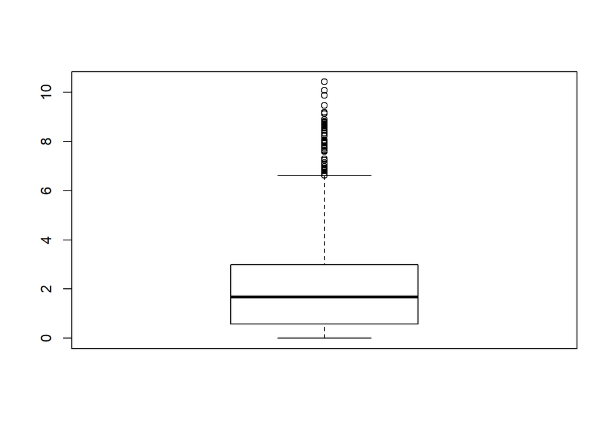

```r
boxplot(df$eviction.rate, plot=TRUE)
```

```r
outliers <- boxplot.stats(df$eviction.rate)
names(outliers)
```

```
## [1] "stats" "n"     "conf"  "out"
```

```r
outliers$out
```

```
##  [1]  8.77 10.42 10.08  7.96  7.98  8.53  7.80  7.09  6.62  6.81  6.98  6.83
## [13]  7.99  8.62  8.71  7.92  7.59  8.22  6.92  7.64  6.87  6.89  7.29  6.86
## [25]  7.15  8.68  8.33  9.19  8.22  7.72  8.26  8.81  9.47  8.88  8.66  8.06
## [37]  6.87  7.30  7.83  7.24  8.81  8.58  9.13  9.88  8.73  8.64  7.62  8.45
## [49]  7.59  6.72
```

### Creating tables (univariate and bivariate)

### Summary Table

There are various packages you can use for creating summary statistics output. One is psych.

```r
install.packages('psych',repos = "http://cran.us.r-project.org")
library(psych)
psych::describe(df) #similar to summary(df)
```

```
##                            vars    n      mean        sd   median   trimmed
## GEOID*                        1 1299     47.51     27.23    49.00     47.80
## year*                         2 1299      9.41      4.80    10.00      9.45
## name*                         3 1299       NaN        NA       NA       NaN
## parent.location*              4 1299       NaN        NA       NA       NaN
## population                    5 1299  67413.48 120011.99 32504.00  41146.39
## poverty.rate                  6 1299      9.58      2.97     9.34      9.46
## renter.occupied.households    7 1299   8159.54  19303.26  2828.00   4092.31
## pct.renter.occupied           8 1299     24.52      5.96    23.23     23.79
## median.gross.rent             9 1299    600.31    115.68   609.00    599.11
## median.household.income      10 1299  45298.81   7254.92 44226.00  44763.00
## median.property.value        11 1299 104765.90  25952.81 99000.00 102758.12
## rent.burden                  12 1299     26.34      3.94    26.30     26.21
## pct.white                    13 1299     92.53      7.22    95.12     93.90
## pct.af.am                    14 1299      2.43      4.52     0.64      1.37
## pct.hispanic                 15 1299      2.95      2.98     1.87      2.35
## pct.am.ind                   16 1299      0.20      0.17     0.18      0.18
## pct.asian                    17 1299      0.69      1.02     0.36      0.46
## pct.nh.pi                    18 1299      0.02      0.04     0.00      0.01
## pct.multiple                 19 1299      1.11      0.68     0.97      1.02
## pct.other                    20 1299      0.07      0.09     0.04      0.05
## eviction.filings             21 1299    703.41   3148.57    76.00    161.64
## evictions                    22 1299    373.27   1487.24    47.00     97.28
## eviction.rate                23 1299      2.14      1.97     1.67      1.85
## eviction.filing.rate         24 1299      3.57      3.48     2.63      2.98
## low.flag                     25 1299      0.20      0.40     0.00      0.13
## imputed                      26 1299      0.03      0.17     0.00      0.00
## subbed                       27 1299      0.00      0.00     0.00      0.00
## year.cat*                    28 1299      1.50      0.50     2.00      1.50
##                                 mad      min       max     range  skew kurtosis
## GEOID*                        35.58     1.00     92.00     91.00 -0.10    -1.24
## year*                          5.93     1.00     17.00     16.00 -0.06    -1.21
## name*                            NA      Inf      -Inf      -Inf    NA       NA
## parent.location*                 NA      Inf      -Inf      -Inf    NA       NA
## population                 21567.38  5623.00 926335.00 920712.00  4.84    27.41
## poverty.rate                   2.92     2.97     20.27     17.30  0.47     0.21
## renter.occupied.households  2019.30   492.00 173265.00 172773.00  6.12    43.14
## pct.renter.occupied            4.58    14.75     47.41     32.66  1.54     3.16
## median.gross.rent            105.26   339.00   1016.00    677.00  0.16     0.22
## median.household.income     6295.12 31362.00  86222.00  54860.00  1.36     4.77
```

[output cut: 32 more lines]

```
## pct.af.am                     0.13
## pct.hispanic                  0.08
## pct.am.ind                    0.00
## pct.asian                     0.03
## pct.nh.pi                     0.00
## pct.multiple                  0.02
## pct.other                     0.00
## eviction.filings             87.36
## evictions                    41.26
## eviction.rate                 0.05
## eviction.filing.rate          0.10
## low.flag                      0.01
## imputed                       0.00
## subbed                        0.00
## year.cat*                     0.01
```

```r
df_desc <- psych::describeBy(df, df$year.cat) #summarizes data by category
class(df_desc)
```

```
## [1] "psych"      "describeBy"
```

```r
names(df_desc)
```

```
## [1] "before.2008" "after.2008"
```

```r
class(df_desc$after.2008)
```

```
## [1] "psych"      "describe"   "data.frame"
```

```r
df_desc_before <- df_desc$before.2008[,c("n","mean","median","sd")]
df_desc_after <- df_desc$after.2008[,c("n","mean","median","sd")]
colnames(df_desc_before) <- paste0(colnames(df_desc_before),".before.2008")
colnames(df_desc_after) <- paste0(colnames(df_desc_after),".after.2008")
df_desc <- cbind(df_desc_before,df_desc_after)
write.csv(df_desc, "summary_statistics_by_year2008.csv")
```

### Correlation Matrix

cor() is the base function. for a visually more appealing version, using lowerCor() from psych pachage is also possible.

```r
df_corvar <- df[,c('eviction.rate','poverty.rate','median.household.income',
                   'median.property.value','pct.white','pct.af.am','pct.asian',
                   'pct.hispanic','pct.am.ind')]
cor(df_corvar)
```

```
##                         eviction.rate poverty.rate median.household.income
## eviction.rate              1.00000000   0.13413973              0.06761565
## poverty.rate               0.13413973   1.00000000             -0.54598215
## median.household.income    0.06761565  -0.54598215              1.00000000
## median.property.value      0.13012506  -0.34129700              0.84157503
## pct.white                 -0.59226864  -0.29995208             -0.10942661
## pct.af.am                  0.56766096   0.34271383             -0.03182550
## pct.asian                  0.22756139   0.08816383              0.23655012
## pct.hispanic               0.39820281   0.09692532              0.21762163
## pct.am.ind                 0.05153926   0.16987714             -0.16681138
##                         median.property.value   pct.white   pct.af.am
## eviction.rate                      0.13012506 -0.59226864  0.56766096
## poverty.rate                      -0.34129700 -0.29995208  0.34271383
## median.household.income            0.84157503 -0.10942661 -0.03182550
## median.property.value              1.00000000 -0.24245524  0.09617548
## pct.white                         -0.24245524  1.00000000 -0.90443921
## pct.af.am                          0.09617548 -0.90443921  1.00000000
## pct.asian                          0.43927441 -0.47365065  0.29166001
## pct.hispanic                       0.24570692 -0.76387218  0.46806889
## pct.am.ind                        -0.18681435 -0.03323854  0.04342561
##                           pct.asian pct.hispanic  pct.am.ind
## eviction.rate            0.22756139   0.39820281  0.05153926
## poverty.rate             0.08816383   0.09692532  0.16987714
## median.household.income  0.23655012   0.21762163 -0.16681138
## median.property.value    0.43927441   0.24570692 -0.18681435
## pct.white               -0.47365065  -0.76387218 -0.03323854
## pct.af.am                0.29166001   0.46806889  0.04342561
## pct.asian                1.00000000   0.26861628 -0.04561183
## pct.hispanic             0.26861628   1.00000000 -0.03408576
## pct.am.ind              -0.04561183  -0.03408576  1.00000000
```

```r
lowerCor(df_corvar)
```

```
##                         evct. pvrt. mdn.h. mdn.p. pct.w pct.f. pct.s pct.h
## eviction.rate            1.00
## poverty.rate             0.13  1.00
## median.household.income  0.07 -0.55  1.00
## median.property.value    0.13 -0.34  0.84   1.00
## pct.white               -0.59 -0.30 -0.11  -0.24   1.00
## pct.af.am                0.57  0.34 -0.03   0.10  -0.90  1.00
## pct.asian                0.23  0.09  0.24   0.44  -0.47  0.29   1.00
## pct.hispanic             0.40  0.10  0.22   0.25  -0.76  0.47   0.27  1.00
## pct.am.ind               0.05  0.17 -0.17  -0.19  -0.03  0.04  -0.05 -0.03
##                         pct.m.
## eviction.rate
## poverty.rate
## median.household.income
## median.property.value
## pct.white
## pct.af.am
## pct.asian
## pct.hispanic
## pct.am.ind               1.00
```

It is also possible to show correlations for two groups in one correlation matrix using psych package. When comparing results from two different groups, it is convenient to display them as one matrix, with the results from one group below the diagonal, and the other group above the diagonal. Use lowerUpper to do this:

```r
df_corvar2 <- df[,c('year.cat',
                   'eviction.rate','poverty.rate','median.household.income',
                   'median.property.value','pct.white','pct.af.am','pct.asian',
                   'pct.hispanic','pct.am.ind')]

before <- subset(df_corvar2,df_corvar2$year.cat=="before.2008")
after <- subset(df_corvar2,df_corvar2$year.cat=="after.2008")
lower <- lowerCor(before[-1])
```

```
##                         evct. pvrt. mdn.h. mdn.p. pct.w pct.f. pct.s pct.h
## eviction.rate            1.00
## poverty.rate             0.07  1.00
## median.household.income  0.13 -0.63  1.00
## median.property.value    0.20 -0.34  0.84   1.00
## pct.white               -0.61 -0.23 -0.10  -0.22   1.00
## pct.af.am                0.58  0.27 -0.01   0.10  -0.92  1.00
## pct.asian                0.35  0.19  0.09   0.36  -0.44  0.30   1.00
## pct.hispanic             0.35  0.00  0.23   0.23  -0.73  0.45   0.24  1.00
## pct.am.ind               0.08  0.21 -0.20  -0.21  -0.07  0.05  -0.06  0.02
##                         pct.m.
## eviction.rate
## poverty.rate
## median.household.income
## median.property.value
## pct.white
## pct.af.am
## pct.asian
## pct.hispanic
## pct.am.ind               1.00
```

```r
upper <- lowerCor(after[-1])
```

```
##                         evct. pvrt. mdn.h. mdn.p. pct.w pct.f. pct.s pct.h
## eviction.rate            1.00
## poverty.rate             0.20  1.00
## median.household.income  0.03 -0.68  1.00
## median.property.value    0.09 -0.48  0.81   1.00
## pct.white               -0.60 -0.33 -0.04  -0.20   1.00
## pct.af.am                0.56  0.40 -0.08   0.08  -0.90  1.00
## pct.asian                0.17  0.00  0.27   0.46  -0.49  0.29   1.00
## pct.hispanic             0.46  0.12  0.12   0.18  -0.78  0.49   0.26  1.00
## pct.am.ind               0.03  0.16 -0.12  -0.15  -0.02  0.04  -0.03 -0.05
##                         pct.m.
## eviction.rate
## poverty.rate
## median.household.income
## median.property.value
## pct.white
## pct.af.am
## pct.asian
## pct.hispanic
## pct.am.ind               1.00
```

```r
both <- lowerUpper(lower,upper)
round(both,2)
```

```
##                         eviction.rate poverty.rate median.household.income
## eviction.rate                      NA         0.20                    0.03
## poverty.rate                     0.07           NA                   -0.68
## median.household.income          0.13        -0.63                      NA
## median.property.value            0.20        -0.34                    0.84
## pct.white                       -0.61        -0.23                   -0.10
## pct.af.am                        0.58         0.27                   -0.01
## pct.asian                        0.35         0.19                    0.09
## pct.hispanic                     0.35         0.00                    0.23
## pct.am.ind                       0.08         0.21                   -0.20
##                         median.property.value pct.white pct.af.am pct.asian
## eviction.rate                            0.09     -0.60      0.56      0.17
## poverty.rate                            -0.48     -0.33      0.40      0.00
## median.household.income                  0.81     -0.04     -0.08      0.27
## median.property.value                      NA     -0.20      0.08      0.46
## pct.white                               -0.22        NA     -0.90     -0.49
## pct.af.am                                0.10     -0.92        NA      0.29
## pct.asian                                0.36     -0.44      0.30        NA
## pct.hispanic                             0.23     -0.73      0.45      0.24
## pct.am.ind                              -0.21     -0.07      0.05     -0.06
##                         pct.hispanic pct.am.ind
## eviction.rate                   0.46       0.03
## poverty.rate                    0.12       0.16
## median.household.income         0.12      -0.12
## median.property.value           0.18      -0.15
## pct.white                      -0.78      -0.02
## pct.af.am                       0.49       0.04
## pct.asian                       0.26      -0.03
## pct.hispanic                      NA      -0.05
## pct.am.ind                      0.02         NA
```

```r
diffs <- lowerUpper(lower,upper,diff=TRUE)
round(diffs,2)
```

```
##                         eviction.rate poverty.rate median.household.income
## eviction.rate                      NA        -0.13                    0.11
## poverty.rate                     0.07           NA                    0.05
## median.household.income          0.13        -0.63                      NA
## median.property.value            0.20        -0.34                    0.84
## pct.white                       -0.61        -0.23                   -0.10
## pct.af.am                        0.58         0.27                   -0.01
## pct.asian                        0.35         0.19                    0.09
## pct.hispanic                     0.35         0.00                    0.23
## pct.am.ind                       0.08         0.21                   -0.20
##                         median.property.value pct.white pct.af.am pct.asian
## eviction.rate                            0.11     -0.01      0.02      0.17
## poverty.rate                             0.14      0.10     -0.13      0.20
## median.household.income                  0.04     -0.06      0.06     -0.17
## median.property.value                      NA     -0.02      0.02     -0.10
## pct.white                               -0.22        NA     -0.02      0.04
## pct.af.am                                0.10     -0.92        NA      0.01
## pct.asian                                0.36     -0.44      0.30        NA
## pct.hispanic                             0.23     -0.73      0.45      0.24
## pct.am.ind                              -0.21     -0.07      0.05     -0.06
##                         pct.hispanic pct.am.ind
## eviction.rate                  -0.11       0.05
## poverty.rate                   -0.12       0.05
## median.household.income         0.11      -0.08
## median.property.value           0.05      -0.05
## pct.white                       0.05      -0.05
## pct.af.am                      -0.04       0.00
## pct.asian                      -0.02      -0.03
## pct.hispanic                      NA       0.07
## pct.am.ind                      0.02         NA
```

```r
write.csv(diffs, "correlation_matrix_by_year2008.csv")
```

We can also see correlations in a heatmap:

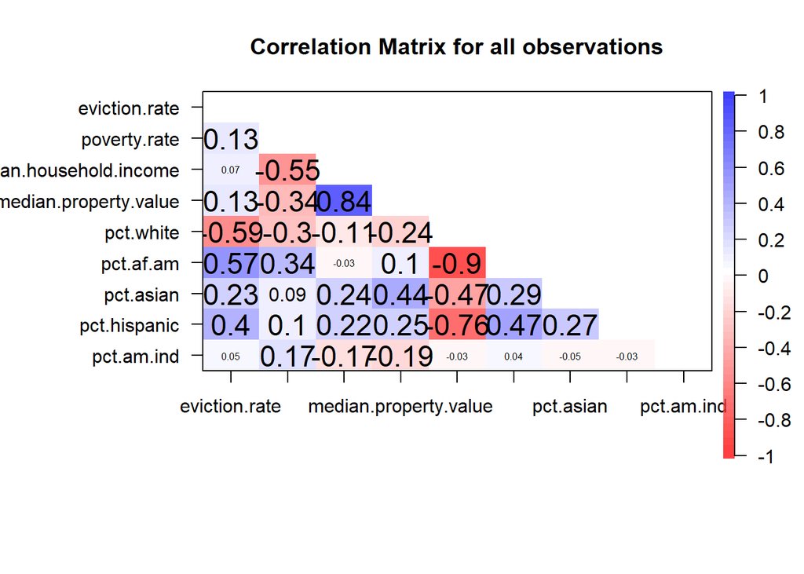

```r
corPlot(df_corvar,main='Correlation Matrix for all observations', diag=FALSE, upper=FALSE)
```

### Contingency tables

To create contingency, or two-way frequency tables, you can use table(). Let’s check the number of observations for each county for the two time periods: before 2008 and after 2008.

```r
mytable <- table(df$name,df$year.cat) # name will be rows, year.cat will be columns
mytable # print table
```

```
##
##                      before.2008 after.2008
##   Adams County                 9          8
##   Allen County                 8          8
##   Bartholomew County           9          8
##   Benton County                9          8
##   Blackford County             9          8
##   Boone County                 6          4
##   Brown County                 9          8
##   Carroll County               8          8
##   Cass County                  7          4
##   Clark County                 8          6
##   Clay County                  9          8
##   Clinton County               8          8
##   Crawford County              9          8
##   Daviess County               9          8
##   Dearborn County              6          2
##   Decatur County               9          8
##   DeKalb County                8          8
##   Delaware County              0          7
##   Dubois County                5          8
##   Elkhart County               0          7
##   Fayette County               2          8
##   Floyd County                 7          8
##   Fountain County              9          8
##   Franklin County              9          8
##   Fulton County                9          8
##   Gibson County                8          8
##   Grant County                 7          8
##   Greene County                2          6
##   Hamilton County              0          7
##   Hancock County               5          8
##   Harrison County              7          8
##   Henry County                 0          7
##   Howard County                5          7
##   Huntington County            2          7
##   Jackson County               6          0
##   Jasper County                9          8
##   Jay County                   9          8
##   Jefferson County             0          6
```

[output cut: 38 more lines]

```
##   Switzerland County           9          8
##   Tippecanoe County            7          8
##   Tipton County                8          8
##   Union County                 9          8
##   Vanderburgh County           9          8
##   Vermillion County            9          6
##   Vigo County                  8          8
##   Wabash County                3          7
##   Warren County                9          8
##   Warrick County               7          8
##   Washington County            7          8
##   Wayne County                 9          8
##   Wells County                 9          8
##   White County                 6          7
##   Whitley County               7          8
```

```r
head(margin.table(mytable, 1)) # name frequencies (summed over year.cat)
```

```
##
##       Adams County       Allen County Bartholomew County      Benton County
##                 17                 16                 17                 17
##   Blackford County       Boone County
##                 17                 10
```

```r
margin.table(mytable, 2)
```

```
##
## before.2008  after.2008
##         647         652
```

```r
prop.table(mytable)[1:5,] # cell percentages, printing first 5 rows only
```

```
##
##                      before.2008  after.2008
##   Adams County       0.006928406 0.006158584
##   Allen County       0.006158584 0.006158584
##   Bartholomew County 0.006928406 0.006158584
##   Benton County      0.006928406 0.006158584
##   Blackford County   0.006928406 0.006158584
```

```r
prop.table(mytable, 1)[1:5,] # row percentages, printing first 5 rows only
```

```
##
##                      before.2008 after.2008
##   Adams County         0.5294118  0.4705882
##   Allen County         0.5000000  0.5000000
##   Bartholomew County   0.5294118  0.4705882
##   Benton County        0.5294118  0.4705882
##   Blackford County     0.5294118  0.4705882
```

```r
prop.table(mytable, 2)[1:5,] # column percentages, printing first 5 rows only
```

```
##
##                      before.2008 after.2008
##   Adams County        0.01391036 0.01226994
##   Allen County        0.01236476 0.01226994
##   Bartholomew County  0.01391036 0.01226994
##   Benton County       0.01391036 0.01226994
##   Blackford County    0.01391036 0.01226994
```

## Plot the data before fitting models

Let’s say we want to explore whether there is a relation between the eviction rate in a county and the racial characteristics of that county. (DV: eviction rate, IVs: pct.white, pct.af.am, pct.am.ind, pct.hispanic, pct.asian). Let’s check whether there is some distinct correlation between those variables visually.

**Note**: Although I will use plot() function for plotting purposes here, there are better plotting tools, such as the ggplot() function from the ggplot2 package. The reason why I am using plot() is mainly due to the time constraints we have. I highly recommend you to learn ggplot(), and I am adding a website that teaches ggplot2 to the resources list above.

Let’s start with one example:

```r
install.packages("scales",repos = "http://cran.us.r-project.org")
```

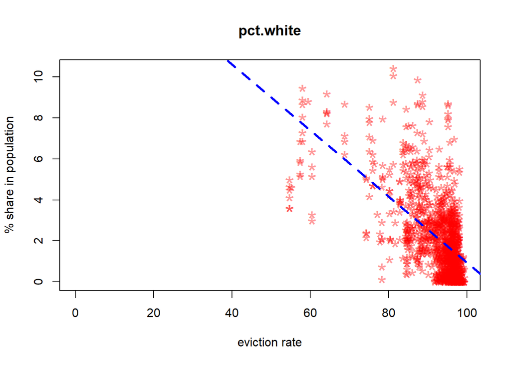

```r
library(scales) # for adding alpha parameter to the graphs
plot(df$pct.white,df$eviction.rate,                                     #plot pct.white on the x axis and eviction.rate on the y axis
     xlim=c(0, max(df$pct.white)), ylim=c(0, max(df$eviction.rate)),    #set minimum and maximum values to be seen on x and y axes
     main="pct.white",                                                  #add plot title
     xlab="eviction rate", ylab="% share in population",                #assign x and y axis labels (the default is the variable names)
     pch="*",                                                           #define the shape of the observations
     col=alpha("red", 0.4),                                             #set the color, and level of transparency
     cex=2)                                                             #set the size for observations
abline(lm(eviction.rate ~ pct.white, data=df),                          #after plotting, add a line y=a+xb (following a linear regression model)
       col="blue", lwd=3, lty=2)                                        #set the color, width and shape (i.e. dashedline) of the line
```

Now let’s draw 5 graphs together using a for loop!

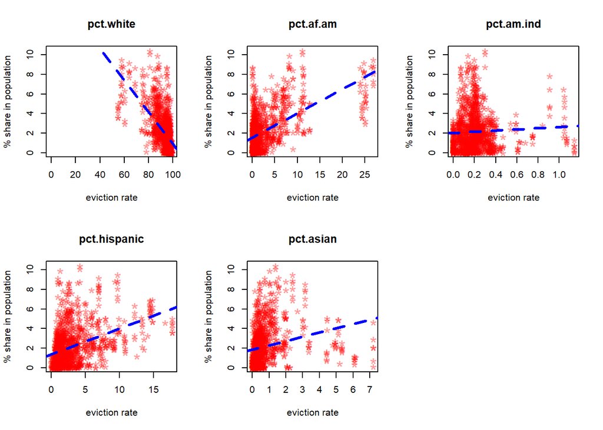

```r
par(mfrow=c(2, 3)) #tell r to align plots by 2x3. We have 5 plots so the last one will be empty.
ivs <- c("pct.white","pct.af.am","pct.am.ind","pct.hispanic","pct.asian")
for (j in ivs){
  plot(df[,j],df$eviction.rate,                                                     #changed: df[,j]
     xlim=c(0, max(df[,j])), ylim=c(0, max(df$eviction.rate)),                      #changed: max(df[,j])
     main=j,                                                                        #changed: j
     xlab="eviction rate", ylab="% share in population",
     pch="*",
     col=alpha("red", 0.4),
     cex=2)
abline(lm(eviction.rate ~ eval(as.name(j)), data=df),                               #changed: eval(as.name(j))
       col="blue", lwd=3, lty=2)
}
```

Let’s check how these plots change when outliers are removed:

```r
keep_rows <- which(df$eviction.rate %in% outliers$out==FALSE)
head(keep_rows)
```

```
## [1] 1 2 3 4 5 6
```

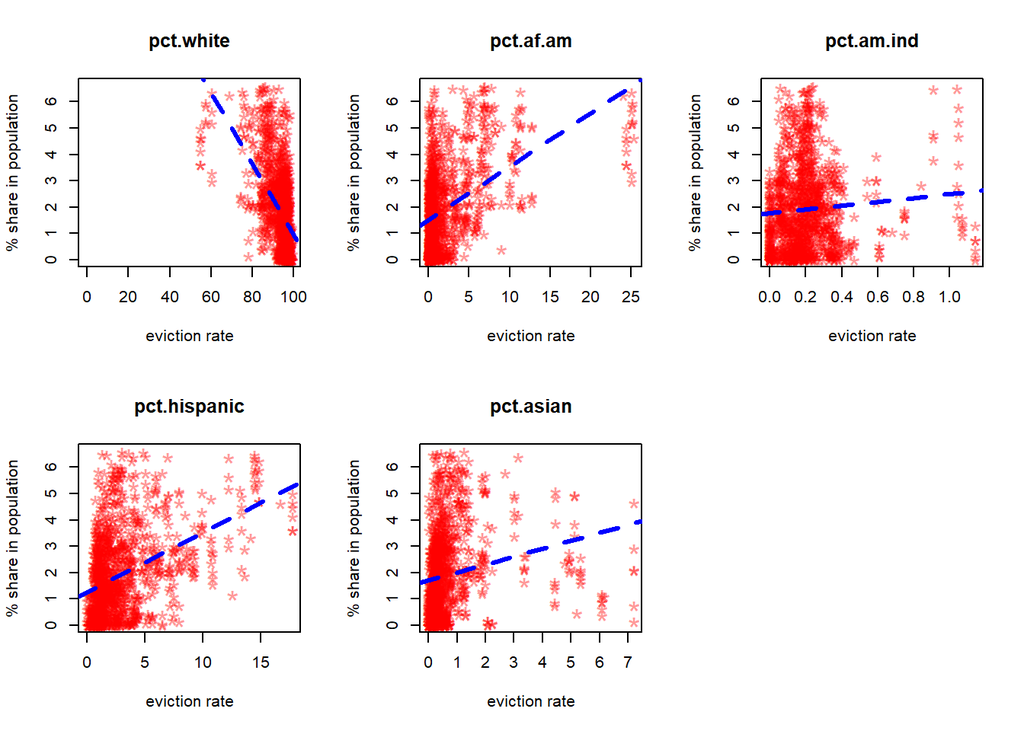

```r
df2 <- df[keep_rows,]
par(mfrow=c(2, 3)) #tell r to align plots by 2x3. We have 5 plots so the last one will be empty.
ivs <- c("pct.white","pct.af.am","pct.am.ind","pct.hispanic","pct.asian")
for (j in ivs){
  plot(df2[,j],df2$eviction.rate,                                                     #changed: df[,j]
     xlim=c(0, max(df2[,j])), ylim=c(0, max(df2$eviction.rate)),                      #changed: max(df[,j])
     main=j,                                                                        #changed: j
     xlab="eviction rate", ylab="% share in population",
     pch="*",
     col=alpha("red", 0.4),
     cex=2)
abline(lm(eviction.rate ~ eval(as.name(j)), data=df2),                               #changed: eval(as.name(j))
       col="blue", lwd=3, lty=2)
}
```